# Machine Learning course

Bernardas

Thursday, May 21, 2015

## Table of contents

This Machine Learning Course’s project writeup consists of:

- Exploratory analysis done
- Choice of algorithm(s)
- Cross validation, expected out of sample error

## Exploratory analysis done

I looked at data using command bellow, some immediate notes follow:

```r
#head(trDs)
```

Notes:

- First column (named “X”) is a sequence number. If I don’t exclude it from predictors set, it will make a perfect tree using this one column; (i.e. if X<5581 then “A” else if …). And it will predict all A’s for test test (and it did when I tried so). Therefore, exclude column X from any further model training

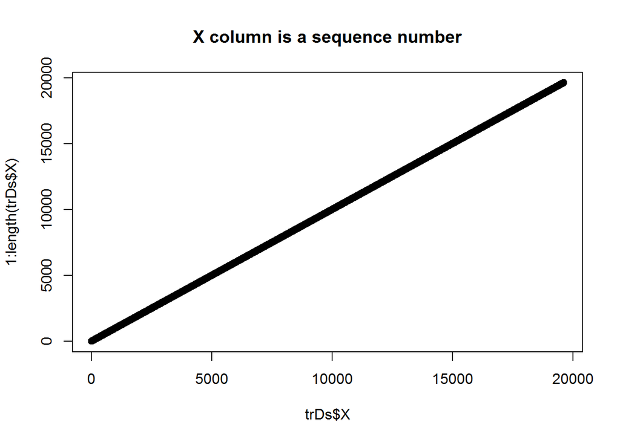

```r
plot(trDs$X,1:length(trDs$X),main="X column is a sequence number")
```

- Most columns appear numeric, but the class is factor. I will convert types of all columns that contain numeric variables to numeric type. I do so because training most algorithms (like glm) can only work with numeric perdictors

```r
#Column counts by type
table(sapply(trDs,class))
```

```
##
##  factor integer numeric
##      37      35      88
```

```r
#Complete cases
length(trDs[complete.cases(trDs),])
```

```
## [1] 160
```

```r
#Column counts by number of NAs and #DIV/0!'s
table(sapply(trDs,function(x){length(x[x=="#DIV/0!" | x=="NA"])}))
```

```
##
##     0     1     2     4     5     9    10    11    32    77    78    80
##    60     1     1     1     4     1     4     2     2     1     1     2
##    83    84    85   406 19216
##     1     4     2     6    67
```

- This is the code that cleans data: changes types and sets values for NAs and #DIV/0!

```r
options(warn=-1)
intcols<-as.character(c())
notcols<-as.character(c())
for (c in colnames(trDs)){
    if (!all(is.na(as.numeric(as.character(trDs[,c]))))){
        #place numeric col name to a vector for reference
        intcols<-rbind(intcols,c)
        #change col type from factor to numeric
        trDs[,c] <- as.numeric(as.character(trDs[,c]))
        #replace NA with median
        mdn <- median(trDs[!is.na(trDs[,c]),c])
        trDs[is.na(trDs[,c]),c] <- mdn

        #some columns e.g. amplitude_yaw_dumbbell have all 0's, they should be removed
        if (max(trDs[,c]) == min(trDs[,c]))
            trDs[,c]<-NULL

        #do the same for test set: change type to factor; replace NAs with median from train set
        tsDs[,c] <- as.numeric(as.character(tsDs[,c]))
        tsDs[is.na(tsDs[,c]),c] <- mdn
    }
    else{
        #place non-numeric col name to a vector for reference
        notcols<-rbind(notcols,c)
        #certain vectors have only 2 values: NA and DIV/0; remove such as they do not carry information
        if (all(levels(trDs[,c]) == c("","#DIV/0!")))
            trDs[,c]<-NULL
    }
}
```

## Choice of algorithm(s)

Considered using a subset of methods taught in video lectures:

- Boosting (method=gbm)
- Random forests (method=rf)
- Generic linear model (method=glm)

### How boosting perfomed?

R code I used to train the model was this:

```r
#training the model using boosting
gbmGrid <-  expand.grid(interaction.depth = 2, n.trees = 10, shrinkage = .1)
gbmtr <- train(classe ~.-X ,data = trDs, method = "gbm", tuneGrid=gbmGrid,verbose=F)
```

When evaluating accuracy, I got 81% rate as in-sample error. This is at most what I could expect for out-of-sample accuracy, and that provided model did not overfit. That’s not good enough :(

```r
#evaluating accuracy
confusionMatrix(predict(gbmtr,trDs),trDs$classe)
```

### How random forests perfomed?

Training with random forests did not finish using the following command bellow in 12 hours. I tried subsetting the data to 5%, and still couldn’t get it to finish in under an hour. My assumption is that one should reduce the number of predictors before training on RF, but I decided to postpone this until other methods (glm in particular) is tried.

```r
#training the model using rf did not finish in 12 hours
rftr<-train(classe ~ .-X, data=trDs, method="rf", prox=TRUE)
```

### How general linear models perfomed?

Since glm works on numeric predicted values, I decided to add dummy variables A,B,C,D, and E for each class, each having values 0 or 1. Then I trained five models, one for each class. Finally, I looked at in-sample accuracy which was 92-97% for all models, which seems quite good.

```r
#instead of factor variable class, add 5 dummy vars A,B,C,D,E
trDs$A <- as.numeric(trDs$classe=="A")
trDs$B <- as.numeric(trDs$classe=="B")
trDs$C <- as.numeric(trDs$classe=="C")
trDs$D <- as.numeric(trDs$classe=="D")
trDs$E <- as.numeric(trDs$classe=="E")

#trained 5 models
mdlglma <- train(A ~. ,data = trDs[,!colnames(trDs) %in% c('B','C','D','E','X','classe')], method = "glm")
mdlglmb <- train(B ~. ,data = trDs[,!colnames(trDs) %in% c('A','C','D','E','X','classe')], method = "glm")
mdlglmc <- train(C ~. ,data = trDs[,!colnames(trDs) %in% c('A','B','D','E','X','classe')], method = "glm")
mdlglmd <- train(D ~. ,data = trDs[,!colnames(trDs) %in% c('A','B','C','E','X','classe')], method = "glm")
mdlglme <- train(E ~. ,data = trDs[,!colnames(trDs) %in% c('A','B','C','D','X','classe')], method = "glm")

#confusion matrix for mdlglma produced 97%, all others were similar
confusionMatrix(abs(round(predict(mdlglma,trDs))),trDs$A)
confusionMatrix(abs(round(predict(mdlglmb,trDs))),trDs$B)
confusionMatrix(abs(round(predict(mdlglmc,trDs))),trDs$C)
confusionMatrix(abs(round(predict(mdlglmd,trDs))),trDs$D)
confusionMatrix(abs(round(predict(mdlglmc,trDs))),trDs$E)
```

In order to find the predicted classe, I took the max of predicted values of columns A,B,C,D,E. Then, evaluate the in-sample accuracy rate for my “blended” model, which consists of MAX(pred(A:E))

```r
trpred<-matrix(rep(0.0,5*length(trDs$X)),ncol=length(trDs$X))
rownames(trpred)<-c('A','B','C','D','E')
trpred["A",]<-predict(mdlglma,trDs)
trpred["B",]<-predict(mdlglmb,trDs)
trpred["C",]<-predict(mdlglmc,trDs)
trpred["D",]<-predict(mdlglmd,trDs)
trpred["E",]<-predict(mdlglme,trDs)
#see the max score having class (save in predClasseTr)
library(nnet)
predClasseTr<-rownames(trpred[apply(trpred, 2, function(x) {which.is.max(x)}),])
#check in sample accuracy: 89%
confusionMatrix(predClasseTr,trDs$classe)
```

## Cross validation, expected out of sample error: 11%

My approach to estimate the out-of-sample error was:

- Divide training data to training (90%) and validation (10%)
- Apply the training algorithm that performed the best (glm) on training data
- Predict values for validation data and compare those predictions against the actual validation data classe
- The error rate of the above will be my estimate for out-of-sample error rate

, I also considered using e.g. 10 folds, but training just once takes significant time (~60min in my case), so I rejected such a cross validation approach, although I assume it could have produced a more accurate out-of-sample error rate’s estimate.

This is my R code:

```r
#divide training data to training (90%) and validation (10%)
smpl <- sample(1:nrow(trDs), round(nrow(trDs)*0.90), replace=FALSE)
trtr90<-trDs[smpl,]
trvld10<-trDs[-smpl,]

#train the models on training data (90%)
mdl90a <- train(A ~. ,data = trtr90[,!colnames(trtr90) %in% c('B','C','D','E','X','classe')], method = "glm")
mdl90b <- train(B ~. ,data = trtr90[,!colnames(trtr90) %in% c('A','C','D','E','X','classe')], method = "glm")
mdl90c <- train(C ~. ,data = trtr90[,!colnames(trtr90) %in% c('A','B','D','E','X','classe')], method = "glm")
mdl90d <- train(D ~. ,data = trtr90[,!colnames(trtr90) %in% c('A','B','C','E','X','classe')], method = "glm")
mdl90e <- train(E ~. ,data = trtr90[,!colnames(trtr90) %in% c('A','B','C','D','X','classe')], method = "glm")

#produce predicted values on validation data (10%)
vldpred<-matrix(rep(0.0,5*length(trvld10$X)),ncol=length(trvld10$X))
rownames(vldpred)<-c('A','B','C','D','E')
vldpred["A",]<-predict(mdl90a,trvld10)
vldpred["B",]<-predict(mdl90b,trvld10)
vldpred["C",]<-predict(mdl90c,trvld10)
vldpred["D",]<-predict(mdl90d,trvld10)
vldpred["E",]<-predict(mdl90e,trvld10)

#answer = the max score having class
predClasseVld<-rownames(vldpred[apply(vldpred, 2, function(x) {which.is.max(x)}),])

#get accuracy (1-error) rate: 89% (out of sample error estimate: 11%)
confusionMatrix(predClasseVld,trvld10$classe)
```

Finally, I had to predict the test data. This is my code to do it:

```r
#store predictions for dummy vars in a matrix
tspred<-matrix(rep(0.0,5*length(tsDs$X)),ncol=length(tsDs$X))
rownames(tspred)<-c('A','B','C','D','E')
tspred["A",]<-predict(mdlglma,tsDs)
tspred["B",]<-predict(mdlglmb,tsDs)
tspred["C",]<-predict(mdlglmc,tsDs)
tspred["D",]<-predict(mdlglmd,tsDs)
tspred["E",]<-predict(mdlglme,tsDs)

#answer = the max score having class
answers<-rownames(tspred[apply(tspred, 2, function(x) {which.is.max(x)}),])
#write answers out to files for submission
pml_write_files = function(x){
    n = length(x)
    for(i in 1:n){
        filename = paste0("problem_id_",i,".txt")
        write.table(x[i],file=filename,quote=FALSE,row.names=FALSE,col.names=FALSE)
    }
}
pml_write_files(answers)
```

Submitted, got 100% correct. This is pretty lucky, I expected only 89% accuracy.